# Analytics Edge: Unit 3 - An Introduction to Logistic Regression

Sulman Khan

October 26, 2018

## Modeling the Expert

### Ask the Experts!

- Critical decisions are often made by people with expert knowledge
- Healthcare Quality Assessment
  - Good quality care educates patients and controls costs
  - Need to assess quality for proper medical interventions
  - No single set of guidelines for defining quality of healthcare
  - Health professionals are experts in quality of care assessment

### Replicating Expert Assessment

- Can we develop analytical tools that replicate expert assessment on a large scale?
- Learn from expert human judgement
  - Develop a model, interpret results, and adjust the model
  - Make predictions/evaluations on a large scale
  - Let’s identify poor healthcare quality using analytics

### Claims Data

- Electronically available
- Standardized
- Not 100% accurate
- Under-reporting is common
- Claims for hospital visits can be vague

### Creating the Dataset

#### Claims Samples

- Large health insurance claims database
- Randomly selected 131 diabetes patients
- Ages range from 35 to 55
- Cost $10,000 - $20,000

#### Expert Review

- Expert physician reviewed claims and wrote descriptive notes.

#### Expert Assessment

- Rated quality on a two-point scale (poor/good)

#### Variable Extraction

- Dependent Variable
  - Quality of care
- Independent Variables
  - Ongoing use of **narcotics**
  - **only on Avandia**, not a good first choice drug
  - Had **regular visits, mammogram, and immunizations**
  - Was given **home testing supplies**
  - Diabetes treatment
  - Patient demographics
  - Healthcare utilization
  - Providers
  - Claims
  - Prescriptions

### Predicting Quality of Care

- The dependent variable is modeled as a binary variable
  - 1 if low-quality case, 0 if high-quality care
- This is a *categorical variable*
  - A small number of possible outcomes
- Linear regression would predict a continuous outcome

### Logistic Regression

- Predicts the probability of poor care
  - Denote the dependent variable “PoorCare” by y
  - $$P(y = 1)$$
- Then
  $$P(y = 0) = 1 - P(y = 1)$$
- Independent variables
  $$x_1, x_2, ..., x_k$$
- Uses the Logistic Response Function
  $$P(y = 1) = \frac{1}{1 + e^{-(\beta_0 + \beta_1 x_1 + \beta_2 x_2 + ... + \beta_k x_k)}}$$

### Understanding the Logistic Function

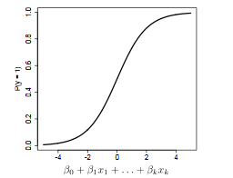

- Positive values are predictive of class 1
- Negative values are predictive of class 0
- The coefficients are selected to
  - Predict a high probability for the poor care cases
  - Predict a low probability for the good care cases
- We can talk about Odds (like in gambling)
  $$Odds = \frac{P(y = 1)}{P(y = 0)}$$
- Odds > 1 if y = 1 is more likely
- Odds < 1 if y = 0 is more likely

### The Logit

$$Odds = e^{\beta_0 + \beta_1 x_1 + \beta_2 x_2 + ... + \beta_k x_k}$$
$$log(Odds) = \beta_0 + \beta_1 x_1 + \beta_2 x_2 + ... + \beta_k x_k$$

- This is called the “Logit” and looks like linear regression
- The bigger the Logit, the bigger P(y = 1)

### Model for Healthcare Quality

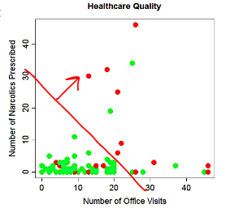

- Plot of the independent variables
  - Number of Office Visits
  - Number of Narcotics Prescribed
- Red are poor care
- Green are good care

### Selecting a Threshold Value

- Compare actual outcomes to predicted outcomes using *a confusion matrix (classification matrix)*

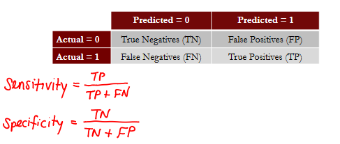

### Receiver Operator Characteristic (ROC) Curve

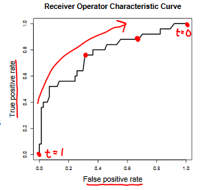

### Selecting a Threshold using ROC

- Captures all thresholds simultaneously
- High Threshold
  - High specificity
  - Low sensitivity
- Low Threshold
  - Low specificity
  - High sensitivity
- Choose **best threshold** for best **best trade off**
  - **cost of failing to detect positives**
  - **costs of raising false alarms**

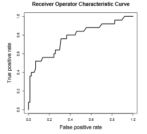

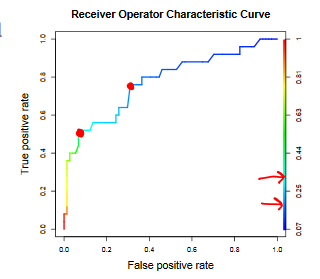

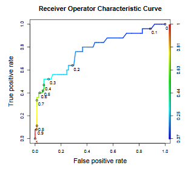

### Intepreting the Model

- Multicollinearity could be a problem
  - Do the coefficients make sense
  - Check correlations
- Measures of accuracy

### Compute Outcome Measures

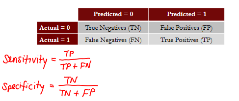

N = number of observations

$$Overall Accuracy = \frac{TN + TP}{N}$$

$$Sensitivity = \frac{TP}{TP + FN}$$

$$Specificity = \frac{TN}{TN + FP}$$

$$Overall Error Rate = \frac{FP + FN}{N}$$

$$False Negative Error Rate = \frac{FN}{TP + FN}$$

$$False Positive Error Rate = \frac{FP}{TN + FP}$$

### Making Predictions

- Just like in linear regression, we want to make predictions on a test set to compute out-of-sample metrics

> predictTest = predict(QualityLog, type = “response”, newdata = qualityTest)
- This makes predictions for probabilities
- If we use a threshold value of 0.3, we get the following confusion matrix

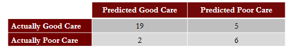

### Area Under the ROC Curve (AUC)

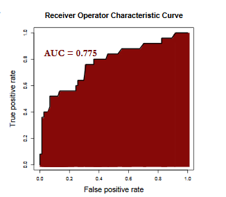

- Just take the area under the curve
- Interpretation
  - Given a random positive and negative proportion of the time you guess which is correct
- Less affected by sample balance than accuracy

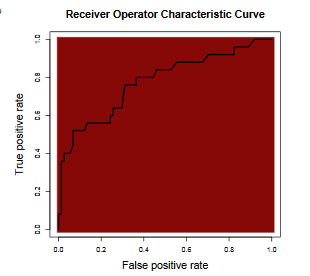

- What is a good AUC?
  - Maximum of 1 (perfect prediction)
- What is a bad AUC?
  - Minimum of 0.5 (just guessing)

### Conclusions

- An expert-trained model can accurately identify diabetics receiving low-quality care
  - Out-of-sample accuracy of 78%
  - Identifies most patients receiving poor care
- In practice, the probabilities returned by the logistic regression model can be used to prioritize patients for intervention
- Electronic medical records could be used in the future

### The Competitive Edge of Models

- While humans can accurately analyze small amounts of information, models allow large scalability
- Models do not replace expert judgement
  - Experts can improve and refine the model
- Models can integrate assessments of many experts into one final unbiased and unemotional prediction.

## Modeling the Expert in R

### Read in dataset

```r
# Read in the dataset
quality = read.csv("quality.csv")
```

### Look at structure

```r
# Output structure
str(quality)
```

```
## 'data.frame':    131 obs. of  14 variables:
##  $ MemberID            : int  1 2 3 4 5 6 7 8 9 10 ...
##  $ InpatientDays       : int  0 1 0 0 8 2 16 2 2 4 ...
##  $ ERVisits            : int  0 1 0 1 2 0 1 0 1 2 ...
##  $ OfficeVisits        : int  18 6 5 19 19 9 8 8 4 0 ...
##  $ Narcotics           : int  1 1 3 0 3 2 1 0 3 2 ...
##  $ DaysSinceLastERVisit: num  731 411 731 158 449 ...
##  $ Pain                : int  10 0 10 34 10 6 4 5 5 2 ...
##  $ TotalVisits         : int  18 8 5 20 29 11 25 10 7 6 ...
##  $ ProviderCount       : int  21 27 16 14 24 40 19 11 28 21 ...
##  $ MedicalClaims       : int  93 19 27 59 51 53 40 28 20 17 ...
##  $ ClaimLines          : int  222 115 148 242 204 156 261 87 98 66 ...
##  $ StartedOnCombination: logi  FALSE FALSE FALSE FALSE FALSE FALSE ...
##  $ AcuteDrugGapSmall   : int  0 1 5 0 0 4 0 0 0 0 ...
##  $ PoorCare            : int  0 0 0 0 0 1 0 0 1 0 ...
```

### Table outcome

```r
# Tabulate the amount of poor care in the dataset
z = table(quality$PoorCare)
kable(z)
```

| Var1 | Freq |
| --- | --- |
| 0 | 98 |
| 1 | 33 |

```r
# Baseline accuracy
98/131
```

```
## [1] 0.7480916
```

### Load caTools package

```r
# Install the caTools to split the training and testing set
library(caTools)

# Randomly split data
set.seed(88)
split = sample.split(quality$PoorCare, SplitRatio = 0.75)
split
```

```
##   [1]  TRUE  TRUE  TRUE  TRUE FALSE  TRUE FALSE  TRUE FALSE FALSE  TRUE FALSE  TRUE  TRUE  TRUE  TRUE  TRUE  TRUE  TRUE  TRUE  TRUE  TRUE  TRUE  TRUE FALSE  TRUE  TRUE  TRUE  TRUE FALSE FALSE FALSE
##  [33] FALSE  TRUE  TRUE  TRUE FALSE  TRUE  TRUE  TRUE FALSE FALSE  TRUE  TRUE FALSE  TRUE FALSE  TRUE FALSE  TRUE  TRUE FALSE FALSE  TRUE  TRUE  TRUE  TRUE  TRUE  TRUE  TRUE  TRUE  TRUE  TRUE  TRUE
##  [65]  TRUE FALSE  TRUE  TRUE  TRUE  TRUE FALSE  TRUE  TRUE  TRUE  TRUE  TRUE  TRUE  TRUE  TRUE  TRUE  TRUE  TRUE  TRUE FALSE  TRUE  TRUE  TRUE  TRUE  TRUE  TRUE  TRUE  TRUE  TRUE FALSE  TRUE  TRUE
##  [97]  TRUE  TRUE  TRUE  TRUE  TRUE  TRUE  TRUE FALSE  TRUE  TRUE  TRUE FALSE  TRUE FALSE FALSE  TRUE  TRUE FALSE  TRUE  TRUE  TRUE FALSE  TRUE  TRUE FALSE  TRUE  TRUE FALSE  TRUE  TRUE FALSE  TRUE
## [129]  TRUE  TRUE FALSE
```

```r
# Create training and testing sets
qualityTrain = subset(quality, split == TRUE)
qualityTest = subset(quality, split == FALSE)
```

### Logistic Regression

```r
# Logistic Regression Model
QualityLog = glm(PoorCare ~ OfficeVisits + Narcotics, data=qualityTrain, family=binomial)
summary(QualityLog)
```

```
##
## Call:
## glm(formula = PoorCare ~ OfficeVisits + Narcotics, family = binomial,
##     data = qualityTrain)
##
## Deviance Residuals:
##      Min        1Q    Median        3Q       Max
## -2.06303  -0.63155  -0.50503  -0.09689   2.16686
##
## Coefficients:
##              Estimate Std. Error z value    Pr(>|z|)
## (Intercept)  -2.64613    0.52357  -5.054 0.000000433 ***
## OfficeVisits  0.08212    0.03055   2.688     0.00718 **
## Narcotics     0.07630    0.03205   2.381     0.01728 *
## ---
## Signif. codes:  0 '***' 0.001 '**' 0.01 '*' 0.05 '.' 0.1 ' ' 1
##
## (Dispersion parameter for binomial family taken to be 1)
##
##     Null deviance: 111.888  on 98  degrees of freedom
## Residual deviance:  89.127  on 96  degrees of freedom
## AIC: 95.127
##
## Number of Fisher Scoring iterations: 4
```

### Make Predictions

```r
# Make predictions on training set
predictTrain = predict(QualityLog, type="response")
```

### Analyze the predictions

```r
# Analyze predictions
summary(predictTrain)
```

```
##    Min. 1st Qu.  Median    Mean 3rd Qu.    Max.
## 0.06623 0.11912 0.15967 0.25253 0.26765 0.98456
```

```r
z = tapply(predictTrain, qualityTrain$PoorCare, mean)
kable(z)
```

|  | x |
| --- | --- |
| 0 | 0.1894512 |
| 1 | 0.4392246 |

### Confusion matrix

```r
# Confusion matrix for threshold of 0.5
z = table(qualityTrain$PoorCare, predictTrain > 0.5)
kable(z)
```

|  | FALSE | TRUE |
| --- | --- | --- |
| 0 | 70 | 4 |
| 1 | 15 | 10 |

```r
# Sensitivity and specificity
10/25
```

```
## [1] 0.4
```

```r
70/74
```

```
## [1] 0.9459459
```

```r
# Confusion matrix for threshold of 0.7
z = table(qualityTrain$PoorCare, predictTrain > 0.7)
kable(z)
```

|  | FALSE | TRUE |
| --- | --- | --- |
| 0 | 73 | 1 |
| 1 | 17 | 8 |

```r
# Sensitivity and specificity
8/25
```

```
## [1] 0.32
```

```r
73/74
```

```
## [1] 0.9864865
```

```r
# Confusion matrix for threshold of 0.2
z = table(qualityTrain$PoorCare, predictTrain > 0.2)
kable(z)
```

|  | FALSE | TRUE |
| --- | --- | --- |
| 0 | 54 | 20 |
| 1 | 9 | 16 |

```r
# Sensitivity and specificity
16/25
```

```
## [1] 0.64
```

```r
54/74
```

```
## [1] 0.7297297
```

### ROCR Curve

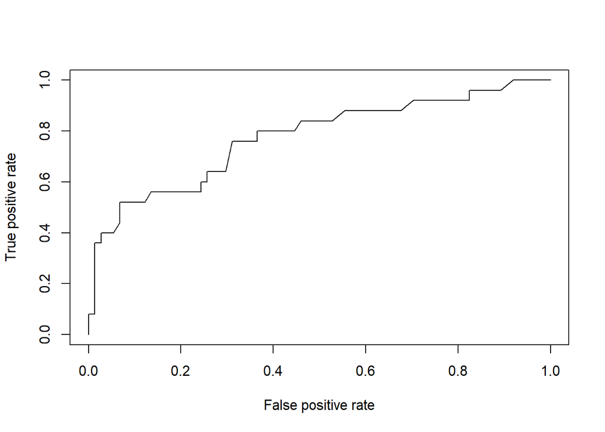

```r
# Load ROCR package
library(ROCR)

# Prediction function
ROCRpred = prediction(predictTrain, qualityTrain$PoorCare)

# Performance function
ROCRperf = performance(ROCRpred, "tpr", "fpr")

# Plot ROC curve
plot(ROCRperf)
```

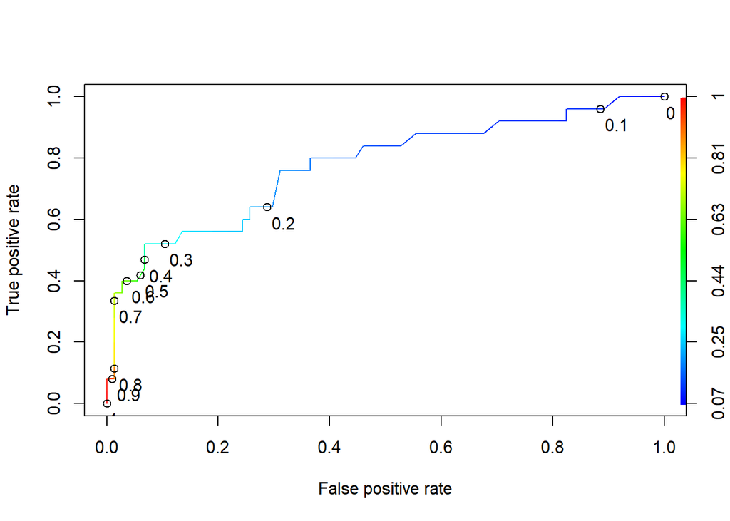

```r
# Add colors
plot(ROCRperf, colorize=TRUE)

# Add threshold labels
plot(ROCRperf, colorize=TRUE, print.cutoffs.at=seq(0,1,by=0.1), text.adj=c(-0.2,1.7))
```